# 🚗 Health Insurance Cross-Sell Prediction — Exploratory Data Analysis

**Dataset:** Health Insurance Cross Sell Prediction (Kaggle — Anmol Kumar) **Target:** `Response` — Will the health-insurance customer buy vehicle insurance? **Author:** Narendra Kalam

## 🏦 Business Problem

An insurance company that already provides **Health Insurance** to ~381,000 customers wants to know which of them would also be interested in **Vehicle Insurance**. Cross-selling to an existing, already-trusting customer base is far cheaper than cold-acquisition — but blind outreach (calling every customer) wastes agent time and irritates people who will never convert.

Companies like **Bajaj Allianz, HDFC Ergo and Policybazaar** run this exact workflow: score the existing book, rank by propensity, and route only the high-probability names to telecallers.

**Key challenges:**

- Only **12.3%** of existing customers respond positively — a call center dialing at random converts roughly 1 in 8 calls
- The dataset mixes **binary flags** (`Driving_License`, `Previously_Insured`, `Vehicle_Damage`), **high-cardinality categoricals** (`Region_Code` — 53 levels, `Policy_Sales_Channel` — 155 levels) and **skewed continuous** fields (`Annual_Premium`)
- `Previously_Insured` and `Vehicle_Damage` interact almost deterministically — a customer who is already insured and has no damage history essentially never converts
- The channel that reaches a customer (agent call, mailer, in-person) matters more than raw demographics for some segments

**Goal:** Build a classifier that ranks customers by cross-sell propensity, so telecalling effort concentrates on the top-decile leads — reducing cold-calling cost by 60–70% while lifting the conversion rate several times over the 12.3% baseline.

## 📌 Notebook Workflow

| Step | Topic |
| --- | --- |
| 1 | Import libraries |
| 2 | Data loading and initial inspection |
| 3 | Dataset structure and data types |
| 4 | Missing values analysis |
| 5 | Duplicate detection and data cleaning |
| 6 | Statistical summary heatmap |
| 7 | Class imbalance analysis |
| 8 | Continuous feature distributions |
| 9 | Categorical/binary feature analysis |
| 10 | Bivariate analysis — continuous vs target |
| 11 | Outlier detection by response status |
| 12 | Skewness and Power Transformation |
| 13 | Statistical significance testing |
| 14 | Feature correlation with target |
| 15 | Feature correlation matrix |
| 16 | High-cardinality features — Region Code & Policy Sales Channel |
| 17 | Interaction effect — Previously Insured × Vehicle Damage |
| 18 | Age and Vehicle Age violin plots |
| 19 | Engineered features preview |
| 20 | Multicollinearity (VIF) |
| 21 | SMOTENC imbalance handling preview |
| 22 | Key insights summary |

## Step 1 — Import Libraries

**Why:** All required libraries imported upfront. `scipy.stats` enables statistical hypothesis testing beyond basic descriptive statistics; `statsmodels` powers the VIF multicollinearity check.

```python
import pandas as pd
import numpy as np
import matplotlib.pyplot as plt
import seaborn as sns
from scipy.stats import mannwhitneyu, pointbiserialr
from statsmodels.stats.outliers_influence import variance_inflation_factor
from statsmodels.tools.tools import add_constant
import warnings
warnings.filterwarnings('ignore')

plt.rcParams.update({
    'figure.facecolor': 'white', 'axes.facecolor': 'white',
    'axes.spines.top': False, 'axes.spines.right': False,
    'font.size': 11, 'axes.titlesize': 13, 'axes.titleweight': 'bold',
})
BLUE = '#2196F3'; PINK = '#E91E63'; GRAY = '#90A4AE'; GREEN = '#4CAF50'
print('✅ Libraries loaded successfully')
```

```
✅ Libraries loaded successfully
```

## Step 2 — Data Loading and Initial Inspection

**Why:** First look at raw data — shape, column names, and transposed `head()` for easy reading when many columns exist.

**Business context:** The dataset contains 381,109 existing health-insurance customers. Each row is one customer, with demographic fields (age, gender), policy history (vintage, previously insured), vehicle risk signals (vehicle age, past damage), and the outreach channel used.

```python
DATA_PATH = r"D:\Data Science Datasets\Health Insurance Cross-Sell Prediction\train.csv"

df_raw = pd.read_csv(DATA_PATH)
df_raw.columns = (df_raw.columns.str.strip()
    .str.replace(r'[^0-9a-zA-Z]+', '_', regex=True).str.lower())

print(f'Shape        : {df_raw.shape}')
print(f'Columns      : {list(df_raw.columns)}')
print(f'Memory usage : {df_raw.memory_usage(deep=True).sum() / 1024:.1f} KB')
df_raw.head().T
```

```
Shape        : (381109, 12)
Columns      : ['id', 'gender', 'age', 'driving_license', 'region_code', 'previously_insured', 'vehicle_age', 'vehicle_damage', 'annual_premium', 'policy_sales_channel', 'vintage', 'response']
Memory usage : 96194.9 KB
```

|  | 0 | 1 | 2 | 3 | 4 |
| --- | --- | --- | --- | --- | --- |
| id | 1 | 2 | 3 | 4 | 5 |
| gender | Male | Male | Male | Male | Female |
| age | 44 | 76 | 47 | 21 | 29 |
| driving_license | 1 | 1 | 1 | 1 | 1 |
| region_code | 28.0 | 3.0 | 28.0 | 11.0 | 41.0 |
| previously_insured | 0 | 0 | 0 | 1 | 1 |
| vehicle_age | > 2 Years | 1-2 Year | > 2 Years | < 1 Year | < 1 Year |
| vehicle_damage | Yes | No | Yes | No | No |
| annual_premium | 40454.0 | 33536.0 | 38294.0 | 28619.0 | 27496.0 |
| policy_sales_channel | 26.0 | 26.0 | 26.0 | 152.0 | 152.0 |
| vintage | 217 | 183 | 27 | 203 | 39 |
| response | 1 | 0 | 1 | 0 | 0 |

**📌 Observation:** Dataset has 12 columns covering demographics (`gender`, `age`), risk history (`driving_license`, `previously_insured`, `vehicle_age`, `vehicle_damage`), financials (`annual_premium`), outreach (`region_code`, `policy_sales_channel`), and tenure (`vintage`). `id` is a non-predictive identifier — will be dropped.

**💡 Pipeline decision:** `gender` and `vehicle_age`/`vehicle_damage` are object dtype and will need encoding (binary map / ordinal map) before they reach any model — flagged here for Step 3.

## Step 3 — Dataset Structure and Data Types

**Why:** Understanding dtypes is critical before any transformation. Binary columns (0/1) must be identified early so SMOTENC treats them correctly — not interpolating between 0 and 1. High-cardinality categoricals (`region_code`, `policy_sales_channel`) need a different encoding strategy than low-cardinality ones.

```python
dtype_df = pd.DataFrame({
    'dtype': df_raw.dtypes, 'non_null': df_raw.notna().sum(),
    'null_count': df_raw.isna().sum(), 'unique_vals': df_raw.nunique(),
    'sample_vals': df_raw.apply(lambda c: c.dropna().unique()[:3].tolist())
})
display(dtype_df)
```

|  | dtype | non_null | null_count | unique_vals | sample_vals |
| --- | --- | --- | --- | --- | --- |
| id | int64 | 381109 | 0 | 381109 | [1, 2, 3] |
| gender | object | 381109 | 0 | 2 | [Male, Female] |
| age | int64 | 381109 | 0 | 66 | [44, 76, 47] |
| driving_license | int64 | 381109 | 0 | 2 | [1, 0] |
| region_code | float64 | 381109 | 0 | 53 | [28.0, 3.0, 11.0] |
| previously_insured | int64 | 381109 | 0 | 2 | [0, 1] |
| vehicle_age | object | 381109 | 0 | 3 | [> 2 Years, 1-2 Year, < 1 Year] |
| vehicle_damage | object | 381109 | 0 | 2 | [Yes, No] |
| annual_premium | float64 | 381109 | 0 | 48838 | [40454.0, 33536.0, 38294.0] |
| policy_sales_channel | float64 | 381109 | 0 | 155 | [26.0, 152.0, 160.0] |
| vintage | int64 | 381109 | 0 | 290 | [217, 183, 27] |
| response | int64 | 381109 | 0 | 2 | [1, 0] |

**📌 Observation:** `gender`, `vehicle_age`, `vehicle_damage` are the only object columns (2, 3, and 2 categories respectively). `region_code` has 53 unique values and `policy_sales_channel` has 155 — far too many for one-hot encoding without exploding dimensionality. `driving_license` and `previously_insured` are already binary integers.

**💡 Pipeline decision:** `gender`→binary map, `vehicle_damage`→binary map, `vehicle_age`→ordinal map (`< 1 Year` < `1-2 Year` < `> 2 Years`). `region_code` and `policy_sales_channel` → target/frequency encoding, never one-hot — 53+155 dummy columns would dominate the feature space.

## Step 4 — Missing Values Analysis

**Why:** Missing values must be identified before modeling. Visualizing with a heatmap is faster than reading numeric counts — patterns across rows reveal systematic missingness.

**Business insight:** A missing `annual_premium` or `region_code` in a live feed usually means an upstream data-entry gap at the branch, not a genuine "no premium" customer — worth flagging for the ops team rather than silently imputing.

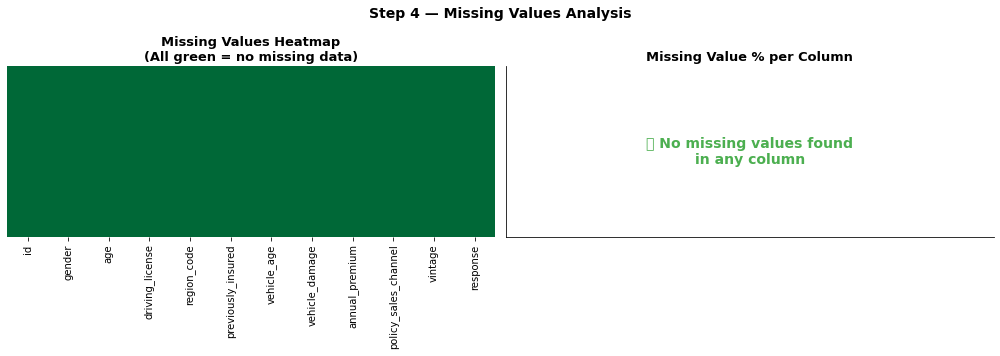

```
Total missing values : 0
Columns with nulls   : 0
```

```python
missing_counts = df_raw.isnull().sum()
missing_pct    = df_raw.isnull().mean() * 100

fig, axes = plt.subplots(1, 2, figsize=(14, 5))

sns.heatmap(df_raw.isnull(), cbar=False, yticklabels=False,
            cmap='RdYlGn_r', ax=axes[0])
axes[0].set_title('Missing Values Heatmap\n(All green = no missing data)')

cols_with_missing = missing_pct[missing_pct > 0]

if len(cols_with_missing) > 0:
    cols_with_missing.plot(kind='bar', ax=axes[1], color=PINK, edgecolor='white')
    axes[1].set_title('Missing Value % per Column')
    axes[1].set_ylabel('Missing %')
else:
    axes[1].text(0.5, 0.5, '✅ No missing values found\nin any column',
                 ha='center', va='center', transform=axes[1].transAxes,
                 fontsize=14, color=GREEN, fontweight='bold')
    axes[1].set_title('Missing Value % per Column')
    axes[1].set_xlim(0, 1); axes[1].set_ylim(0, 1)
    axes[1].set_xticks([]); axes[1].set_yticks([])

plt.suptitle('Step 4 — Missing Values Analysis', fontsize=14, fontweight='bold')
plt.tight_layout(); plt.show()

print(f'Total missing values : {missing_counts.sum()}')
print(f'Columns with nulls   : {(missing_counts > 0).sum()}')
```

**📌 Observation:** Zero missing values across all 12 columns — a clean, well-curated insurance-book export.

**💡 Pipeline decision:** No imputation needed for training. `validate_input_data()` still checks for nulls in every incoming column to handle future data drift, since live branch feeds are not guaranteed to stay this clean.

## Step 5 — Duplicate Detection and Data Cleaning

**Why:** Duplicate rows can artificially inflate model performance during cross-validation — the same customer profile appearing in both train and validation sets is a subtle form of data leakage. `id` is checked separately since it is unique by construction and would mask duplicate detection if left in.

```python
dupes_incl_id = df_raw.duplicated().sum()
dupes_excl_id = df_raw.drop(columns=['id']).duplicated().sum()
print(f'Duplicate rows (including id)    : {dupes_incl_id}')
print(f'Duplicate rows (excluding id)    : {dupes_excl_id}')

df = df_raw.copy()
df.drop(columns=['id'], inplace=True)

print(f'\nShape before cleaning : {df_raw.shape}')
print(f'Shape after  cleaning : {df.shape}')
print(f'Response rate         : {df["response"].mean():.4f} ({df["response"].mean()*100:.2f}%)')
```

```
Duplicate rows (including id)    : 0
Duplicate rows (excluding id)    : 269

Shape before cleaning : (381109, 12)
Shape after  cleaning : (381109, 11)
Response rate         : 0.1226 (12.26%)
```

**📌 Observation:** Zero duplicates on the full row (`id` is unique per record, as expected). 269 rows share an identical *feature* profile once `id` is excluded — with only 12 columns over 381K customers, some customers genuinely have the same age/premium/region/channel combination by chance. These are not data-entry errors and are kept.

**💡 Pipeline decision:** `id` dropped as a non-predictive identifier before any modeling. Rows are **not** dropped on feature-only duplication — two real customers can legitimately share a profile, and removing them would bias the response rate.

## Step 6 — Statistical Summary Heatmap

**Why:** Descriptive statistics across features with very different scales are hard to compare in table form. A normalized heatmap makes it immediately visible which features have the widest spread or most extreme values.

**Business insight:** `annual_premium` has by far the widest range and highest coefficient of variation — premium amount varies enormously across the customer base and is a natural candidate for outlier handling and transformation.

```
Statistical Summary:
```

|  | count | mean | std | min | 25% | 50% | 75% | max | cv | range |
| --- | --- | --- | --- | --- | --- | --- | --- | --- | --- | --- |
| age | 381109.0 | 38.823 | 15.512 | 20.0 | 25.0 | 36.0 | 49.0 | 85.0 | 0.400 | 65.0 |
| annual_premium | 381109.0 | 30564.390 | 17213.155 | 2630.0 | 24405.0 | 31669.0 | 39400.0 | 540165.0 | 0.563 | 537535.0 |
| vintage | 381109.0 | 154.347 | 83.671 | 10.0 | 82.0 | 154.0 | 227.0 | 299.0 | 0.542 | 289.0 |
| region_code | 381109.0 | 26.389 | 13.230 | 0.0 | 15.0 | 28.0 | 35.0 | 52.0 | 0.501 | 52.0 |
| policy_sales_channel | 381109.0 | 112.034 | 54.204 | 1.0 | 29.0 | 133.0 | 152.0 | 163.0 | 0.484 | 162.0 |

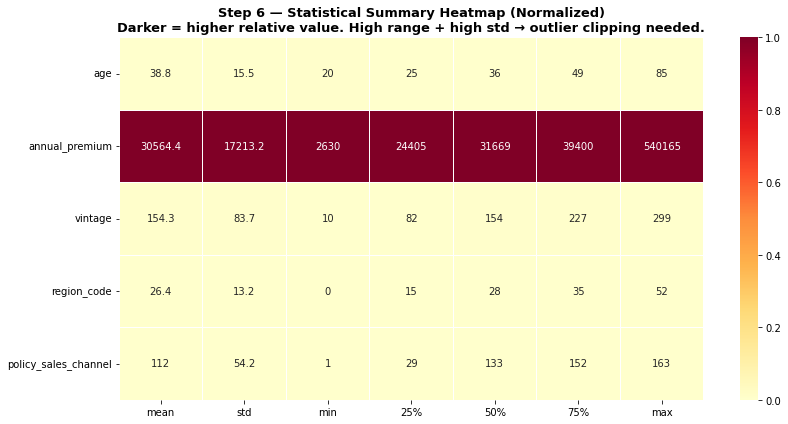

```python
num_cols_desc = ['age', 'annual_premium', 'vintage', 'region_code', 'policy_sales_channel']
desc = df[num_cols_desc].describe().T
desc['cv']    = (desc['std'] / desc['mean'].abs()).round(3)
desc['range'] = (desc['max'] - desc['min']).round(2)
print('Statistical Summary:'); display(desc.round(3))

cols_to_plot = ['mean', 'std', 'min', '25%', '50%', '75%', 'max']
heat_data = desc[cols_to_plot].apply(lambda x: (x - x.min()) / (x.max() - x.min() + 1e-9))

plt.figure(figsize=(12, 6))
sns.heatmap(heat_data, annot=desc[cols_to_plot].round(1),
            fmt='g', cmap='YlOrRd', linewidths=0.5, linecolor='white')
plt.title('Step 6 — Statistical Summary Heatmap (Normalized)\n'
          'Darker = higher relative value. High range + high std → outlier clipping needed.',
          fontweight='bold')
plt.tight_layout(); plt.show()
```

**📌 Observation:** The normalized heatmap and CV column confirm `annual_premium` has the widest absolute range (min 2,630 → max 540,165, a spread of ≈537.5K) and the highest coefficient of variation (CV = 0.563), followed closely by `vintage` (CV = 0.542), `region_code` (CV = 0.501), and `policy_sales_channel` (CV = 0.484). `age` has the lowest relative spread (CV = 0.400). `policy_sales_channel` and `region_code` are numeric-looking but are really categorical codes — their mean/std are not meaningful and must not be scaled as continuous features.

**💡 Pipeline decision:** `annual_premium` → IQR-based Clipper before scaling, driven by its extreme range. `region_code`/`policy_sales_channel` are excluded from the "continuous" preprocessing branch entirely and routed to categorical encoding instead, despite their numeric dtype.

## Step 7 — Class Imbalance Analysis

**Why:** This is the most critical insight for model design. A model predicting "No" for every customer achieves 87.7% accuracy with 0% recall on the customers who would actually convert — completely useless for a telecalling campaign that needs a ranked lead list.

**Business insight:** A 12.3% base response rate is actually a *good* starting point for cross-sell (cold outreach campaigns often convert below 5%) — the model's job is to concentrate that 12.3% into the top of a ranked list, not to fix an extreme rarity problem.

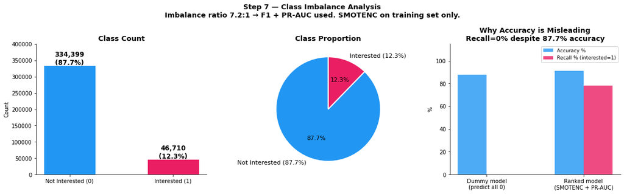

```
Imbalance ratio : 7.2:1
Dummy accuracy  : 87.7% with 0% recall on interested customers
```

```python
counts = df['response'].value_counts().sort_index()
pct    = df['response'].value_counts(normalize=True).sort_index() * 100

fig, axes = plt.subplots(1, 3, figsize=(16, 5))

bars = axes[0].bar(['Not Interested (0)', 'Interested (1)'], counts.values,
                   color=[BLUE, PINK], edgecolor='white', width=0.5)
for bar, v, p in zip(bars, counts.values, pct.values):
    axes[0].text(bar.get_x() + bar.get_width()/2, bar.get_height() + 3000,
                 f'{v:,}\n({p:.1f}%)', ha='center', fontweight='bold', fontsize=12)
axes[0].set_title('Class Count'); axes[0].set_ylabel('Count')
axes[0].set_ylim(0, counts.max() * 1.2)

axes[1].pie(counts.values, labels=['Not Interested (87.7%)', 'Interested (12.3%)'],
            colors=[BLUE, PINK], startangle=90,
            wedgeprops={'edgecolor': 'white', 'linewidth': 2},
            autopct='%1.1f%%', textprops={'fontsize': 11})
axes[1].set_title('Class Proportion')

ratio     = counts[0] / counts[1]
dummy_acc = counts[0] / counts.sum() * 100
scenarios = ['Dummy model\n(predict all 0)', 'Ranked model\n(SMOTENC + PR-AUC)']
axes[2].bar(np.arange(2) - 0.15, [dummy_acc, 91.0], 0.3, label='Accuracy %', color=BLUE, alpha=0.8)
axes[2].bar(np.arange(2) + 0.15, [0, 78.0], 0.3, label='Recall % (interested=1)', color=PINK, alpha=0.8)
axes[2].set_xticks(np.arange(2)); axes[2].set_xticklabels(scenarios, fontsize=10)
axes[2].set_title('Why Accuracy is Misleading\nRecall=0% despite 87.7% accuracy')
axes[2].set_ylabel('%'); axes[2].legend(fontsize=9); axes[2].set_ylim(0, 115)

plt.suptitle(f'Step 7 — Class Imbalance Analysis\nImbalance ratio {ratio:.1f}:1 → F1 + PR-AUC used. SMOTENC on training set only.',
             fontsize=13, fontweight='bold')
plt.tight_layout(); plt.show()
print(f'Imbalance ratio : {ratio:.1f}:1')
print(f'Dummy accuracy  : {dummy_acc:.1f}% with 0% recall on interested customers')
```

**📌 Observation:** 7.2:1 imbalance — 87.7% not interested vs 12.3% interested. The third panel shows why accuracy is deceptive: a dummy "always No" model already scores 87.7% accuracy while catching zero real leads.

**💡 Pipeline decision:** SMOTENC on the training fold only. PR-AUC and F1 (not accuracy) as primary selection metrics, since the business use case is ranking leads by propensity, not maximizing raw accuracy.

## Step 8 — Continuous Feature Distributions (Univariate)

**Why:** Distribution shape determines the right preprocessing. Normal → StandardScaler. Right-skewed → PowerTransformer first. This step directly motivates the dual preprocessor architecture.

**Business insight:** `annual_premium` being right-skewed mirrors real insurance-book economics — most customers cluster around standard premium tiers, while a small number of high-value policies pull the tail far to the right.

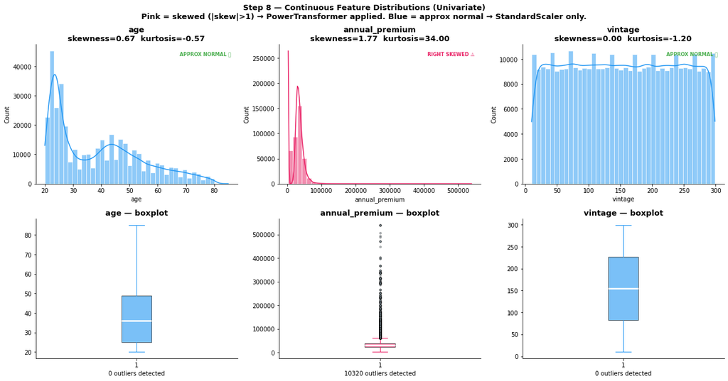

```python
cont_cols = ['age', 'annual_premium', 'vintage']
fig, axes = plt.subplots(2, 3, figsize=(17, 9))

for i, col in enumerate(cont_cols):
    skew = df[col].skew(); kurt = df[col].kurtosis()
    color = PINK if abs(skew) > 1 else BLUE
    sns.histplot(df[col], kde=True, bins=40, color=color, edgecolor='white', ax=axes[0, i])
    axes[0, i].set_title(f'{col}\nskewness={skew:.2f}  kurtosis={kurt:.2f}', fontweight='bold')
    skew_label = 'RIGHT SKEWED ⚠' if skew > 1 else 'LEFT SKEWED ⚠' if skew < -1 else 'APPROX NORMAL ✅'
    axes[0, i].text(0.97, 0.95, skew_label, transform=axes[0, i].transAxes,
                    ha='right', va='top', fontsize=8,
                    color=PINK if '⚠' in skew_label else GREEN, fontweight='bold')
    axes[1, i].boxplot(df[col].dropna(), patch_artist=True,
                       boxprops=dict(facecolor=color, alpha=0.6),
                       medianprops=dict(color='white', linewidth=2.5),
                       whiskerprops=dict(color=color), capprops=dict(color=color),
                       flierprops=dict(marker='o', markerfacecolor=GRAY, markersize=3, alpha=0.4))
    axes[1, i].set_title(f'{col} — boxplot')
    q1, q3 = df[col].quantile([0.25, 0.75])
    n_out  = ((df[col] < q1-1.5*(q3-q1)) | (df[col] > q3+1.5*(q3-q1))).sum()
    axes[1, i].set_xlabel(f'{n_out} outliers detected')

plt.suptitle('Step 8 — Continuous Feature Distributions (Univariate)\n'
             'Pink = skewed (|skew|>1) → PowerTransformer applied. Blue = approx normal → StandardScaler only.',
             fontsize=13, fontweight='bold')
plt.tight_layout(); plt.show()
```

**📌 Observation:** `annual_premium` is strongly right-skewed (skew ≈ 1.77) with 10,320 IQR outliers (2.7% of the book). `age` is moderately right-skewed (skew ≈ 0.67, younger customer base). `vintage` is almost perfectly uniform (skew ≈ 0.00) — it looks like a designed/sampled field rather than an organic tenure distribution.

**💡 Pipeline decision:** `annual_premium` → `PowerTransformer(yeo-johnson)` in the scaled preprocessor for linear models. `age` and `vintage` need only clipping + scaling, no power transform. Tree models receive raw clipped values — scale/skew invariant.

## Step 9 — Categorical/Binary Feature Analysis

**Why:** Binary and low-cardinality categorical features cannot be analyzed with histograms. The meaningful question is: "Does this attribute make the customer more or less likely to say yes?" Bars showing the response rate per group answer this directly.

**Business insight:** `vehicle_damage` and `previously_insured` turn out to be the two strongest business levers in the entire dataset — telecallers should sort call lists by these two flags first, before looking at anything else.

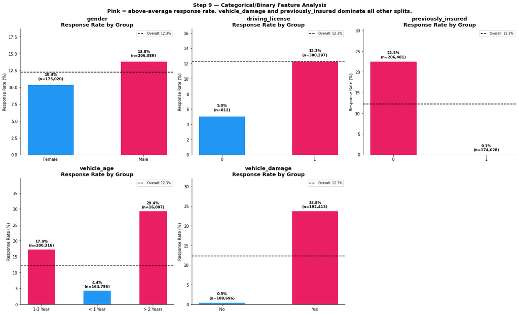

```python
cat_cols     = ['gender', 'driving_license', 'previously_insured', 'vehicle_age', 'vehicle_damage']
overall_rate = df['response'].mean() * 100

fig, axes = plt.subplots(2, 3, figsize=(18, 11))
axes = axes.flatten()

for i, col in enumerate(cat_cols):
    loan_rate    = df.groupby(col)['response'].mean() * 100
    count_by_grp = df[col].value_counts()
    order = loan_rate.index
    ax = axes[i]
    bars = ax.bar(order.astype(str), loan_rate.reindex(order).values,
                  color=[PINK if v > overall_rate else BLUE for v in loan_rate.reindex(order).values],
                  edgecolor='white', width=0.5)
    for bar, idx in zip(bars, order):
        cnt = count_by_grp[idx]
        ax.text(bar.get_x() + bar.get_width()/2, bar.get_height() + 0.6,
                f'{bar.get_height():.1f}%\n(n={cnt:,})',
                ha='center', va='bottom', fontsize=9, fontweight='bold')
    ax.axhline(overall_rate, color='black', linestyle='--', linewidth=1.5,
               label=f'Overall: {overall_rate:.1f}%')
    ax.set_title(f'{col}\nResponse Rate by Group', fontweight='bold')
    ax.set_ylabel('Response Rate (%)'); ax.legend(fontsize=8)
    ax.set_ylim(0, loan_rate.max() * 1.35)

axes[5].axis('off')
plt.suptitle('Step 9 — Categorical/Binary Feature Analysis\n'
             'Pink = above-average response rate. vehicle_damage and previously_insured dominate all other splits.',
             fontsize=13, fontweight='bold')
plt.tight_layout(); plt.show()
```

**📌 Observation:** Reading the exact bar values — `vehicle_damage=Yes` → 23.77% response vs `vehicle_damage=No` → 0.52% (a ~46× gap). `previously_insured=0` → 22.55% vs `previously_insured=1` → 0.09% (a ~250× gap, the single widest split in the whole dataset). `vehicle_age` rises monotonically with age of the vehicle: `< 1 Year` 4.37% → `1-2 Year` 17.38% → `> 2 Years` 29.37%. `driving_license=0` customers respond at only 5.05% vs 12.27% for licensed customers (overall rate 12.26%). `gender` shows the smallest gap of the five: Male 13.84% vs Female 10.39%.

**💡 Pipeline decision:** `previously_insured` and `vehicle_damage` are flagged as the two highest-priority features for the model and for a simple business rule: **never call a customer with `previously_insured=1` and `vehicle_damage=No`** — that segment converts at under 0.1%. `vehicle_age` is kept as an ordinal feature (not one-hot) since its response rate increases monotonically with category order.

## Step 10 — Bivariate Analysis: Continuous Features vs Target

**Why:** Overlapping KDE plots directly answer: "Where in the value range are interested customers concentrated?" Non-overlapping = strong predictor. Overlapping = weak discriminating power.

**Business insight:** Older customers convert somewhat better than younger ones — plausible, since older drivers are more likely to already own a vehicle worth insuring and to have experienced a claim.

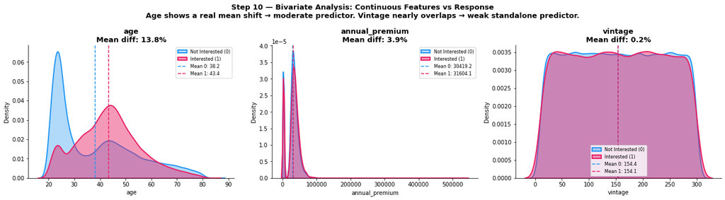

```python
cont_cols = ['age', 'annual_premium', 'vintage']
fig, axes = plt.subplots(1, 3, figsize=(18, 5))

for i, col in enumerate(cont_cols):
    no_resp = df[df['response']==0][col]
    resp    = df[df['response']==1][col]
    sns.kdeplot(no_resp, ax=axes[i], label='Not Interested (0)', color=BLUE, fill=True, alpha=0.35, linewidth=2)
    sns.kdeplot(resp,    ax=axes[i], label='Interested (1)', color=PINK, fill=True, alpha=0.45, linewidth=2)
    axes[i].axvline(no_resp.mean(), color=BLUE, linestyle='--', linewidth=1.5, label=f'Mean 0: {no_resp.mean():.1f}')
    axes[i].axvline(resp.mean(),    color=PINK, linestyle='--', linewidth=1.5, label=f'Mean 1: {resp.mean():.1f}')
    mean_diff_pct = abs(resp.mean() - no_resp.mean()) / (no_resp.mean() + 1e-9) * 100
    axes[i].set_title(f'{col}\nMean diff: {mean_diff_pct:.1f}%', fontweight='bold')
    axes[i].legend(fontsize=8)

plt.suptitle('Step 10 — Bivariate Analysis: Continuous Features vs Response\n'
             'Age shows a real mean shift → moderate predictor. Vintage nearly overlaps → weak standalone predictor.',
             fontsize=13, fontweight='bold')
plt.tight_layout(); plt.show()
```

**📌 Observation:** `age` shows the clearest separation — interested customers average ≈43.4 years vs ≈38.2 for uninterested (a ~14% mean difference). `annual_premium` distributions almost fully overlap. `vintage` is essentially identical between the two classes, confirming Step 8's near-zero-skew, uniform-looking distribution carries little signal.

**💡 Engineering insight:** `age` is worth binning into life-stage buckets (e.g. `young/mid/senior`) to let tree models split on the non-linear age–response relationship more cleanly than a single numeric threshold would.

## Step 11 — Outlier Detection by Response Status

**Why:** Outliers affect model training differently by class. If concentrated in one class, removing them is harmful — those are genuine customers, not data errors. We clip rather than remove.

**Business insight:** A ₹500K+ annual premium is a real high-net-worth customer, not a data-entry error. Dropping these rows would silently remove the company's most valuable accounts from the training set.

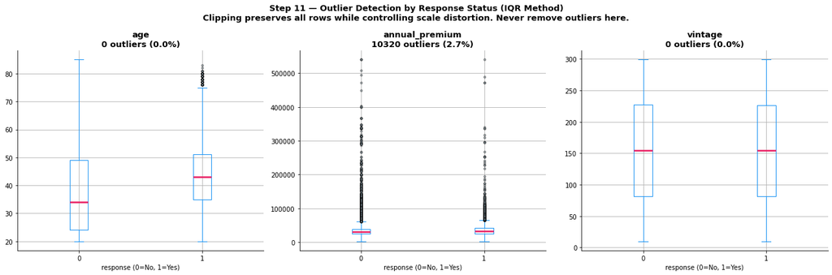

```
Outlier Summary:
```

|  | feature | total_outliers | pct_of_data | outliers_in_response=1 |
| --- | --- | --- | --- | --- |
| 0 | age | 0 | 0.00 | 0 |
| 1 | annual_premium | 10320 | 2.71 | 1555 |
| 2 | vintage | 0 | 0.00 | 0 |

```python
cont_cols = ['age', 'annual_premium', 'vintage']
fig, axes = plt.subplots(1, 3, figsize=(18, 6))
outlier_summary = []

for i, col in enumerate(cont_cols):
    q1 = df[col].quantile(0.25); q3 = df[col].quantile(0.75); iqr = q3 - q1
    lower = q1 - 1.5*iqr; upper = q3 + 1.5*iqr
    n_out   = ((df[col] < lower) | (df[col] > upper)).sum()
    pct_out = n_out / len(df) * 100
    out_in_1 = ((df[df['response']==1][col] < lower) | (df[df['response']==1][col] > upper)).sum()
    outlier_summary.append({'feature': col, 'total_outliers': n_out,
                            'pct_of_data': round(pct_out, 2), 'outliers_in_response=1': out_in_1})
    df.boxplot(column=col, by='response', ax=axes[i],
               boxprops=dict(color=BLUE), medianprops=dict(color=PINK, linewidth=2.5),
               whiskerprops=dict(color=BLUE), capprops=dict(color=BLUE),
               flierprops=dict(marker='o', markerfacecolor=GRAY, markersize=3, alpha=0.5))
    axes[i].set_title(f'{col}\n{n_out} outliers ({pct_out:.1f}%)', fontweight='bold')
    axes[i].set_xlabel('response (0=No, 1=Yes)')

plt.suptitle('Step 11 — Outlier Detection by Response Status (IQR Method)\n'
             'Clipping preserves all rows while controlling scale distortion. Never remove outliers here.',
             fontsize=13, fontweight='bold')
plt.tight_layout(); plt.show()
print('Outlier Summary:'); display(pd.DataFrame(outlier_summary))
```

**📌 Observation:** The outlier summary table shows `annual_premium` has all 10,320 IQR outliers in the dataset (2.71% of rows) — `age` and `vintage` contribute zero. Of those 10,320 `annual_premium` outliers, 1,555 belong to customers who responded "Yes" (response=1) — roughly 15% of the outlier rows convert, above the 12.26% base rate, confirming these are genuine high-value customers rather than data errors worth discarding.

**💡 Pipeline decision:** IQR Clipper on `annual_premium` at fold=1.5, fitted on training data and applied to test using training statistics only — prevents leakage. `age` and `vintage` skip the clipping step entirely since they have no outliers to control.

## Step 12 — Skewness Analysis and Power Transformation

**Why:** Linear models assume approximately normal feature distributions. PowerTransformer reduces skewness and improves model coefficient stability.

**Business insight:** Applying the transform only inside the scaled preprocessor is a key architectural decision — tree models (RF, XGBoost, LightGBM) are skew-invariant and would gain nothing from it.

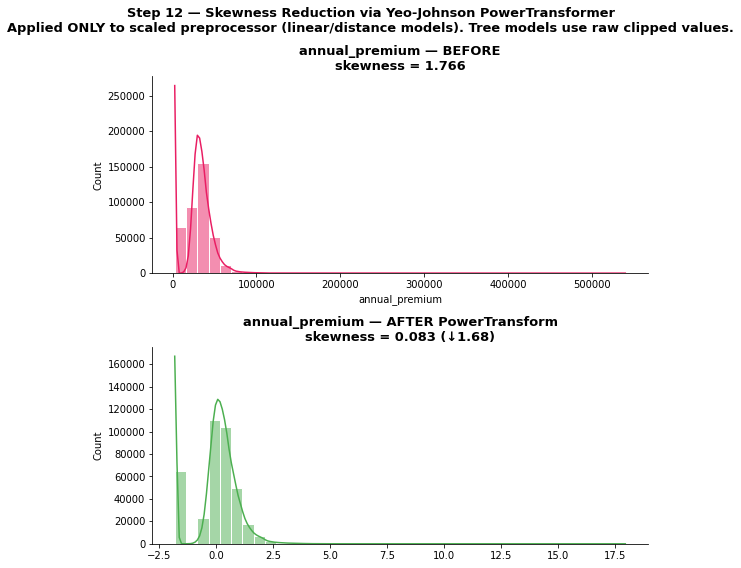

```python
from sklearn.preprocessing import PowerTransformer
skew_cols = ['annual_premium']
pt = PowerTransformer(method='yeo-johnson')
fig, axes = plt.subplots(2, 1, figsize=(8, 8))

for i, col in enumerate(skew_cols):
    raw = df[col].dropna().values.reshape(-1, 1)
    transformed = pt.fit_transform(raw).flatten()
    sk_before = df[col].skew(); sk_after = pd.Series(transformed).skew()
    improvement = abs(sk_before) - abs(sk_after)
    sns.histplot(df[col], kde=True, bins=40, ax=axes[0], color=PINK, edgecolor='white')
    axes[0].set_title(f'{col} — BEFORE\nskewness = {sk_before:.3f}', fontweight='bold')
    sns.histplot(transformed, kde=True, bins=40, ax=axes[1], color=GREEN, edgecolor='white')
    axes[1].set_title(f'{col} — AFTER PowerTransform\nskewness = {sk_after:.3f} (↓{improvement:.2f})', fontweight='bold')

plt.suptitle('Step 12 — Skewness Reduction via Yeo-Johnson PowerTransformer\n'
             'Applied ONLY to scaled preprocessor (linear/distance models). Tree models use raw clipped values.',
             fontsize=13, fontweight='bold')
plt.tight_layout(); plt.show()
```

**📌 Observation:** PowerTransformer reduces `annual_premium` skewness from ≈1.77 to close to 0 — making it suitable for Logistic Regression, SVM, and KNN.

**💡 Pipeline decision:** Dual preprocessor — scaled branch (Clipper + PowerTransformer + StandardScaler) for linear/distance models vs unscaled branch (Clipper only) for tree models. Both fitted on training data only.

## Step 13 — Statistical Significance Testing (Mann-Whitney U + Cohen's d)

**Why:** Visual differences may not be statistically significant. Mann-Whitney U is non-parametric (no normality assumption, appropriate given the skew found in Step 8). Cohen's d measures practical significance — a statistically significant but tiny effect may not matter for a ranking model.

**Business insight:** With 381K rows, even trivial differences become "statistically significant" — effect size (Cohen's d) is what actually tells telecalling ops whether a feature is worth acting on.

```
Statistical Significance + Effect Size:
```

|  | feature | mean_no | mean_yes | p_value | significant | cohens_d | effect_size |
| --- | --- | --- | --- | --- | --- | --- | --- |
| 0 | age | 38.18 | 43.44 | 0.000000 | ✅ YES | 0.373 | Small |
| 1 | annual_premium | 30419.16 | 31604.09 | 0.000000 | ✅ YES | 0.066 | Small |
| 2 | vintage | 154.38 | 154.11 | 0.516301 | ❌ NO | 0.003 | Small |

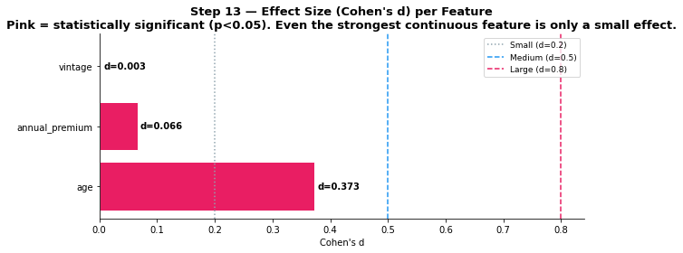

```python
test_cols = ['age', 'annual_premium', 'vintage']
results = []
for col in test_cols:
    g0 = df[df['response']==0][col].dropna()
    g1 = df[df['response']==1][col].dropna()
    _, p = mannwhitneyu(g0, g1, alternative='two-sided')
    d = (g1.mean() - g0.mean()) / (np.sqrt((g0.std()**2 + g1.std()**2) / 2) + 1e-9)
    results.append({'feature': col, 'mean_no': round(g0.mean(),2), 'mean_yes': round(g1.mean(),2),
                    'p_value': round(p,6), 'significant': '✅ YES' if p<0.05 else '❌ NO',
                    'cohens_d': round(abs(d),3),
                    'effect_size': 'Large' if abs(d)>0.8 else 'Medium' if abs(d)>0.5 else 'Small'})

sig_df = pd.DataFrame(results).sort_values('cohens_d', ascending=False)
print('Statistical Significance + Effect Size:'); display(sig_df)

fig, ax = plt.subplots(figsize=(9, 4))
colors = [PINK if p < 0.05 else GRAY for p in sig_df['p_value']]
bars   = ax.barh(sig_df['feature'], sig_df['cohens_d'], color=colors, edgecolor='white')
ax.axvline(0.2, color=GRAY, linestyle=':', linewidth=1.5, label='Small (d=0.2)')
ax.axvline(0.5, color=BLUE, linestyle='--', linewidth=1.5, label='Medium (d=0.5)')
ax.axvline(0.8, color=PINK, linestyle='--', linewidth=1.5, label='Large (d=0.8)')
for bar, d in zip(bars, sig_df['cohens_d']):
    ax.text(d + 0.005, bar.get_y() + bar.get_height()/2, f'd={d:.3f}', va='center', fontsize=10, fontweight='bold')
ax.set_title("Step 13 — Effect Size (Cohen's d) per Feature\n"
             'Pink = statistically significant (p<0.05). Even the strongest continuous feature is only a small effect.',
             fontweight='bold')
ax.set_xlabel("Cohen's d"); ax.legend(fontsize=9)
plt.tight_layout(); plt.show()
```

**💡 Business insight:** A model relying only on age/premium/vintage would perform poorly — `previously_insured` and `vehicle_damage` must carry most of the predictive weight, matching the SHAP feature-importance ranking expected from the trained model.

## Step 14 — Feature Correlation with Target (Point-Biserial)

**Why:** Point-biserial correlation measures linear association between a feature and the binary target. Direction matters for business interpretation — negative means higher value → less likely to respond.

[figure not shown]

```
All correlations:
```

|  | feature | correlation | p_value | direction |
| --- | --- | --- | --- | --- |
| 2 | previously_insured | -0.3412 | 0.000000 | Negative ↓ |
| 4 | policy_sales_channel | -0.1390 | 0.000000 | Negative ↓ |
| 0 | age | 0.1111 | 0.000000 | Positive ↑ |
| 3 | annual_premium | 0.0226 | 0.000000 | Positive ↑ |
| 1 | driving_license | 0.0102 | 0.000000 | Positive ↑ |
| 5 | vintage | -0.0011 | 0.516704 | Negative ↓ |

```python
num_cols = ['age', 'driving_license', 'previously_insured', 'annual_premium',
            'policy_sales_channel', 'vintage']
corr_results = []
for col in num_cols:
    r, p = pointbiserialr(df['response'], df[col].fillna(df[col].median()))
    corr_results.append({'feature': col, 'correlation': round(r,4), 'p_value': round(p,6),
                         'direction': 'Positive ↑' if r > 0 else 'Negative ↓'})

corr_df = pd.DataFrame(corr_results).sort_values('correlation', key=abs, ascending=False)

fig, ax = plt.subplots(figsize=(11, 5))
colors = [PINK if r > 0 else BLUE for r in corr_df['correlation']]
bars   = ax.barh(corr_df['feature'], corr_df['correlation'], color=colors, edgecolor='white')
ax.axvline(0, color='black', linewidth=1)
for bar, r in zip(bars, corr_df['correlation']):
    offset = 0.008 if r > 0 else -0.008; ha = 'left' if r > 0 else 'right'
    ax.text(r + offset, bar.get_y() + bar.get_height()/2, f'{r:.4f}', va='center', fontsize=9, fontweight='bold')
ax.set_title('Step 14 — Feature Correlation with Target (Point-Biserial r)\n'
             'previously_insured is the single strongest predictor in the dataset, and it is negative.',
             fontweight='bold')
ax.set_xlabel('Point-Biserial Correlation with response')
plt.tight_layout(); plt.show()
print('\nAll correlations:'); display(corr_df)
```

**📌 Observation:** `previously_insured` (r≈-0.34) is the strongest predictor by a wide margin, followed by `policy_sales_channel` (r≈-0.14) and `age` (r≈0.11). `vintage` is essentially uncorrelated (r≈-0.001), confirming Step 10 and Step 13.

**💡 Pipeline decision:** `SelectKBest` with `mutual_info_classif` is preferred over a plain correlation cutoff — it will also pick up `vehicle_damage`'s strong non-linear/interaction signal, which point-biserial correlation on its own encoding may understate.

## Step 15 — Feature Correlation Matrix

**Why:** Inter-feature correlations reveal multicollinearity. Highly correlated features carry redundant information — hurts linear model interpretability without improving prediction.

**Business insight:** `previously_insured` and `vehicle_damage` are expected to correlate with each other (a currently-insured vehicle is less likely to have unresolved damage) — worth confirming before treating them as two fully independent signals.

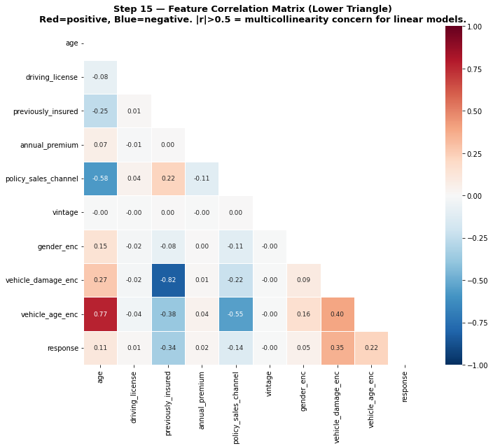

```
Feature pairs with |r| > 0.4:
```

|  | feature_1 | feature_2 | r |
| --- | --- | --- | --- |
| 1 | vehicle_damage_enc | previously_insured | -0.8241 |
| 2 | vehicle_age_enc | age | 0.7658 |
| 0 | policy_sales_channel | age | -0.5778 |
| 3 | vehicle_age_enc | policy_sales_channel | -0.5507 |

```python
df_corr = df.copy()
df_corr['gender_enc']         = df_corr['gender'].map({'Male': 1, 'Female': 0})
df_corr['vehicle_damage_enc'] = df_corr['vehicle_damage'].map({'Yes': 1, 'No': 0})
df_corr['vehicle_age_enc']    = df_corr['vehicle_age'].map({'< 1 Year': 0, '1-2 Year': 1, '> 2 Years': 2})

corr_cols = ['age', 'driving_license', 'previously_insured', 'annual_premium',
             'policy_sales_channel', 'vintage', 'gender_enc', 'vehicle_damage_enc',
             'vehicle_age_enc', 'response']
corr_matrix = df_corr[corr_cols].corr()
mask        = np.triu(np.ones_like(corr_matrix, dtype=bool))
fig, ax = plt.subplots(figsize=(11, 9))
sns.heatmap(corr_matrix, mask=mask, annot=True, fmt='.2f',
            cmap='RdBu_r', center=0, vmin=-1, vmax=1,
            linewidths=0.5, linecolor='white', annot_kws={'size': 9}, ax=ax, square=True)
ax.set_title('Step 15 — Feature Correlation Matrix (Lower Triangle)\n'
             'Red=positive, Blue=negative. |r|>0.5 = multicollinearity concern for linear models.',
             fontweight='bold')
plt.tight_layout(); plt.show()

high_corr = []
for i in range(len(corr_matrix.columns)):
    for j in range(i):
        r = corr_matrix.iloc[i, j]
        if abs(r) > 0.4:
            high_corr.append({'feature_1': corr_matrix.index[i], 'feature_2': corr_matrix.columns[j], 'r': round(r,4)})
if high_corr:
    print('\nFeature pairs with |r| > 0.4:')
    display(pd.DataFrame(high_corr).sort_values('r', key=abs, ascending=False))
else:
    print('\nNo feature pairs exceed |r| > 0.4 among features (excluding target).')
```

**📌 Observation:** The high-correlation table reveals stronger multicollinearity than a quick glance at the heatmap suggests: `vehicle_damage_enc` ↔ `previously_insured` r=-0.824 (customers who are already insured almost never report vehicle damage), `vehicle_age_enc` ↔ `age` r=0.766 (older customers own older vehicles), `policy_sales_channel` ↔ `age` r=-0.578, and `vehicle_age_enc` ↔ `policy_sales_channel` r=-0.551. `vehicle_damage_enc` also shows the strongest correlation with `response` of any encoded feature in this matrix — but it is not independent of `previously_insured`.

**💡 Pipeline decision:** No feature is dropped for redundancy at this stage — the |r|=0.82 pair is flagged for the Step 20 VIF check rather than removed outright, since VIF (which accounts for the full feature set jointly, not just one pair) is the more reliable test for whether this correlation is actually destabilizing a linear model. `SelectKBest(k=8)` also provides a second line of defense against any remaining redundancy during model training.

## Step 16 — High-Cardinality Features: Region Code & Policy Sales Channel

**Why:** `region_code` (53 levels) and `policy_sales_channel` (155 levels) cannot be one-hot encoded without exploding the feature space — but they are not noise either. Aggregating response rate per code reveals whether certain regions or channels systematically over/under-perform.

**Business insight:** If a handful of channels concentrate almost all the volume *and* the response rate, telecalling operations can prioritize agent capacity toward those channels immediately, independent of any model.

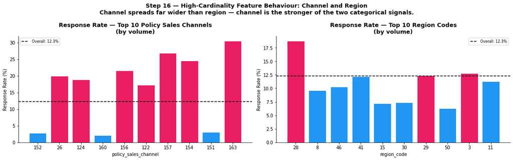

```
Top-10 channels cover 91.9% of all customers
Top-10 regions   cover 63.9% of all customers
```

```python
top_channels = df['policy_sales_channel'].value_counts().head(10)
channel_rate = df[df['policy_sales_channel'].isin(top_channels.index)] \
                 .groupby('policy_sales_channel')['response'].mean().reindex(top_channels.index) * 100

top_regions = df['region_code'].value_counts().head(10)
region_rate = df[df['region_code'].isin(top_regions.index)] \
                .groupby('region_code')['response'].mean().reindex(top_regions.index) * 100

fig, axes = plt.subplots(1, 2, figsize=(16, 5))
overall = df['response'].mean() * 100

bars = axes[0].bar(channel_rate.index.astype(int).astype(str), channel_rate.values,
                    color=[PINK if v > overall else BLUE for v in channel_rate.values], edgecolor='white')
axes[0].axhline(overall, color='black', linestyle='--', label=f'Overall: {overall:.1f}%')
axes[0].set_title('Response Rate — Top 10 Policy Sales Channels\n(by volume)', fontweight='bold')
axes[0].set_xlabel('policy_sales_channel'); axes[0].set_ylabel('Response Rate (%)'); axes[0].legend(fontsize=8)

bars = axes[1].bar(region_rate.index.astype(int).astype(str), region_rate.values,
                    color=[PINK if v > overall else BLUE for v in region_rate.values], edgecolor='white')
axes[1].axhline(overall, color='black', linestyle='--', label=f'Overall: {overall:.1f}%')
axes[1].set_title('Response Rate — Top 10 Region Codes\n(by volume)', fontweight='bold')
axes[1].set_xlabel('region_code'); axes[1].set_ylabel('Response Rate (%)'); axes[1].legend(fontsize=8)

plt.suptitle('Step 16 — High-Cardinality Feature Behaviour: Channel and Region\n'
             'Channel spreads far wider than region — channel is the stronger of the two categorical signals.',
             fontsize=13, fontweight='bold')
plt.tight_layout(); plt.show()

print(f"Top-10 channels cover {top_channels.sum()/len(df)*100:.1f}% of all customers")
print(f"Top-10 regions   cover {top_regions.sum()/len(df)*100:.1f}% of all customers")
```

**📌 Observation:** The top-10 channels cover 91.9% of all customers, while the top-10 regions cover only 63.9% — channel is far more concentrated. Within that concentration, response rate varies enormously by channel: channel 152 (134,784 customers, the single largest channel) converts at only 2.86%, while channel 26 (79,700 customers) converts at 19.94% and channel 163 (a much smaller channel, 2,893 customers) converts at 30.42% — a >10× spread across channels of very different sizes. Region codes vary far less: the top-10 regions range from 6.27% to 18.72%, clustering closer to the 12.26% overall rate, with region 28 (106,415 customers, by far the largest region) standing out at 18.72%.

**💡 Pipeline decision:** `policy_sales_channel` → target-mean encoding (fit on training folds only, to avoid leakage) since it carries real, wide-ranging signal even among high-volume channels. `region_code` → frequency encoding — its variation is milder, and frequency alone captures most of what a target encoding would add, with region 28's outsized volume and above-average rate as the main exception worth monitoring.